# Lecture #13: Implicit Differentiation

MATH 145 – Calculus I

Torin Quinlivan

tquinlivan@knox.edu

Knox College

October 16, 2025

## Implicitly-Defined Functions

So far, we’ve worked solely with functions that can be described explicitly in terms of $x$, i.e. $f(x) = x^3 + 2x^2 + 3x + 4$.

But not all curves can be described this way.

## Examples of Implicitly-Defined Functions

The most obvious example is a circle. Here is the plot of $x^2 + y^2 = 16$, the circle centered at the origin with radius $4$:

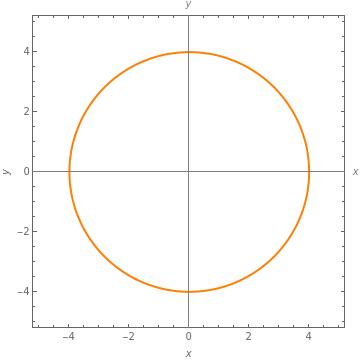

## Examples of Implicitly-Defined Functions

Here is the plot of $x^3 - y^3 = 6xy$:

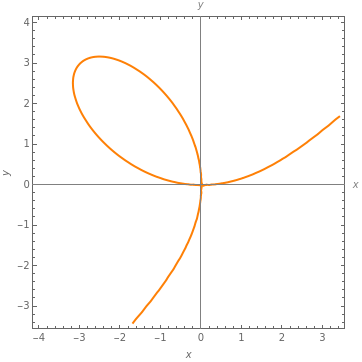

## Examples of Implicitly-Defined Functions

What if we want to find the rate of change of the function $x^2 + y^2 = 16$ at the point $\left( 2\sqrt{2}, 2\sqrt{2} \right)$?

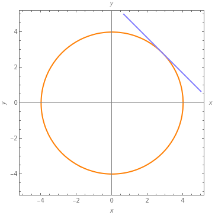

## Implicit Differentiation

Consider the circle $x^2 + y^2 = 16$.

We can’t differentiate the normal way, but what if we think of $y$ as a implicit function of $x$, but which we can differentiate?

Now we can’t find the derivative all the way, we won’t know the derivative, $\dfrac{dy}{dx}$, directly (yet). But we can use the Chain Rule!

## Example #1: Implicit Differentiation

$$\begin{align*}
\dfrac{d}{dx} \Big[ x^2 + y^2 \Big] &= \dfrac{d}{dx} [16] \\
\dfrac{d}{dx} \Big[ x^2 \Big] + \dfrac{d}{dx} \Big[ y^2 \Big] &= 0 \\
2x + 2y \dfrac{dy}{dx} &= 0
\end{align*}$$

## Example: Implicit Differentiation

From here, solve for $\dfrac{dy}{dx}$ to find the form of the derivative:
$$\begin{align*}
2x + 2y \dfrac{dy}{dx} &= 0 \\
2y \dfrac{dy}{dx} &= -2x \\
\dfrac{dy}{dx} &= -\dfrac{2x}{2y} = -\dfrac{x}{y}
\end{align*}$$

What is the slope of the tangent line at $\left( 2, 2\sqrt{3} \right)$?

## Example: Implicit Differentiation

**Examples:**

1. Find the slope of the tangent line of the curve $y^3 + x^3 - 3xy = 0$ at the point $\left( \dfrac{3}{2},\, \dfrac{3}{2} \right)$.
2. Find a formula for $\dfrac{dy}{dx}$ for the curve $x = y^5 - 5y^3 + 4y$.
3. Where does the graph $x = y^5 - 5y^3 + 4y$ have a vertical tangent line?

## Example: Implicit Differentiation

Consider the curve given by the equation $2y^3 + y^2 - y^5 = x^4 - 2x^3 + x^2$.

1. Find the formula for $\dfrac{dy}{dx}$.
2. Where is the tangent line horizontal?
3. Where is the tangent line vertical?

## Related Rates

Consider a right triangle with the three sides changing. How can we relate the rates of change of the lengths of the three sides?

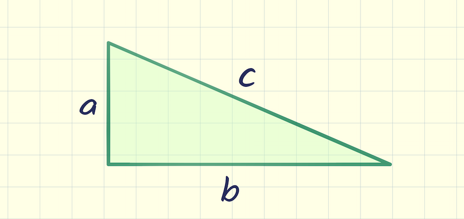

## Related Rates

The three sides are related through the Pythagorean Theorem $a^2 + b^2 = c^2$.

Each of the lengths of the three sides of the triangle are changing as a function of time, but are also tied to each other.

## Related Rates

So what if we derive all three in terms of the time, $t$?

$$\begin{align*}
\dfrac{d}{dt} \Big[ a^2 + b^2 \Big] &= \dfrac{d}{dt} \Big[ c^2 \Big] \\
\dfrac{d}{dt} \Big[ a^2 \Big] + \dfrac{d}{dt} \Big[ b^2 \Big] &= \dfrac{d}{dt} \Big[ c^2 \Big] \\
2a \dfrac{da}{dt} + 2b \dfrac{db}{dt} &= 2c \dfrac{dc}{dt}
\end{align*}$$

Now if we know the rates of change of two of the sides, we can tell the rate of change of the third definitively.

## Example: Related Rates

Water is draining from the bottom of a cone-shaped funnel at a rate of $0.03 \frac{ft^3}{sec}$. The height of the funnel is $2$ feet and the radius at the top of the funnel is $1$ foot. At what rate is the height of the water in the funnel changing when the height of the water is $\dfrac{1}{2}$ feet?